# Homework 2: Geodesics and Manifold Statistics

### Plot of Eigenvalues

```
[4.28871327e-02 3.77712401e-19 9.95435753e-04 5.08870261e-03
 3.53516641e-03 3.28042690e-19]
[[-3.10033623e-01  5.77350269e-01 -6.37402106e-01 -2.68331058e-01
   3.03747952e-01  5.77002564e-01]
 [ 2.93856356e-01  5.77350269e-01  6.41379954e-01 -2.72625859e-01
   3.07606898e-01  5.77002564e-01]
 [ 1.61772676e-02  5.77350269e-01 -3.97784881e-03  5.40956917e-01
  -6.11354851e-01  5.77002564e-01]
 [ 3.49614244e-01 -1.66692594e-15 -1.64765211e-01  5.33482399e-01
   4.82374857e-01  2.00343420e-02]
 [ 3.88185201e-01 -1.77008239e-15 -1.83712420e-01 -5.25714164e-01
  -4.53710569e-01  2.00343420e-02]
 [-7.37799445e-01 -1.27103119e-15  3.48477630e-01 -7.76823537e-03
  -2.86642873e-02  2.00343420e-02]]
```

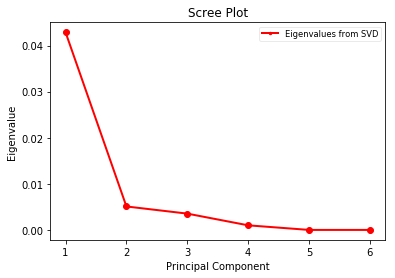

```python
# print(triangles[0].matrix)
# print(triangles[0].matrix.flatten())
flattenedTriangles = []
for triangle in triangles:
    flattenedTriangles.append(triangle.matrix.flatten())
flattenedTriangles = np.array(flattenedTriangles)
# print(flattenedTriangles.shape)
# print(flattenedTriangles)
eigenvalues, eigenvectors = pca(flattenedTriangles)
sortedValueVectorPairs = sorted([(eigenvalues[i], eigenvectors[:, i]) for i in range(len(eigenvalues))], reverse=True)
sortedEigenvalues = [pair[0] for pair in sortedValueVectorPairs]
sortedEigenVectors = [pair[1] for pair in sortedValueVectorPairs]
print(eigenvalues)
print(eigenvectors)
sing_vals = np.arange(eigenvalues.shape[0]) + 1
plt.plot(sing_vals, sortedEigenvalues, 'ro-', linewidth=2)
plt.title('Scree Plot')
plt.xlabel('Principal Component')
plt.ylabel('Eigenvalue')
#I don't like the default legend so I typically make mine like below, e.g.
#with smaller fonts and a bit transparent so I do not cover up data, and make
#it moveable by the viewer in case upper-right is a bad place for it
leg = plt.legend(['Eigenvalues from SVD'], loc='best', borderpad=0.3,
                 shadow=False, prop=matplotlib.font_manager.FontProperties(size='small'),
                 markerscale=0.4)
leg.get_frame().set_alpha(0.4)
leg.draggable(state=True)
plt.show()
```

I would use only 1 mode, since from 2 onwards we don't gain much variance from adding more modes.

### Modes of Variation

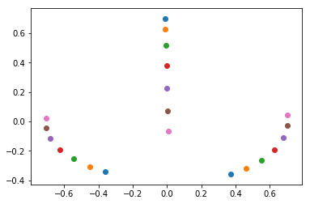

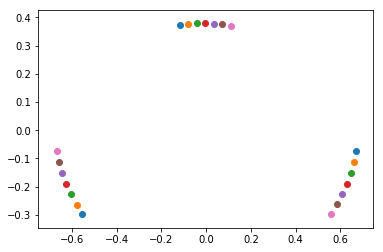

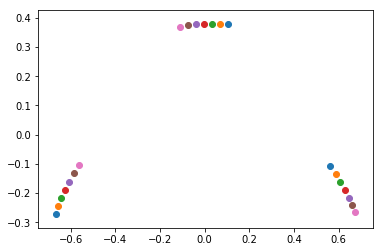

```python
# print(mean.matrix)
# mean.plot()
# plt.show()

for i in range(3):
    # largest eigen value
    lambdai = sortedEigenvalues[i]
    vi = sortedEigenVectors[i]
    v = vi.reshape(2, 3)
    # print(c)
    for t in range(-3, 4):
        mode = mean.expMap(t*lambdai**0.5*v)
#         print(mode.matrix)
        mode.plot()
    plt.show()
    #     plt.show()
# plt.show()
```

It was a bit different than what I expected, especially the first mode of variation. It is a bit counterintuitive that the top vertex of one of the triangles would go below the other side vertices as none of the triangles in the dataset looked like this.

## Corpus Callosum Experiment

```python
import os
def loadShape(fileName):
    lines = open(fileName).read().strip().split("\n")
    # print(test)
    points = [[float(coordinate.split(' ')[0]), float(coordinate.split(' ')[1])] for coordinate in lines]
    return points

folder = "cc-shapes/"
files = os.listdir(folder)
# print(files)
shapes = []
for fileName in files:
    shapes.append(loadShape(folder + fileName))
# print(len(shapes))
# print(shapes)
shapes = [Shape(shape) for shape in shapes]
print(len(shapes))
for i in range(len(shapes)):
    shapes[i].project()
```

```
32
```

### Geodesic between 2 Objects

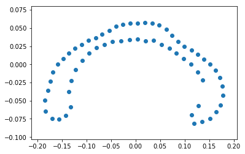

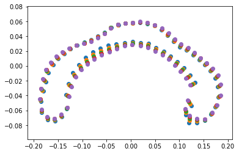

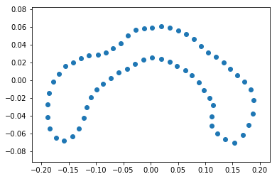

```python
shapes[0].plot()
axes = plt.gca()
# axes.set_xlim([-1,1])
# axes.set_ylim([-1,1])
plt.show()
start = copy.deepcopy(shapes[0])
end = shapes[16]
for i in range(5):
    tangent = start.logMap(end) * 0.2
    start = start.expMap(tangent)
    start.plot()
    axes = plt.gca()
#     axes.set_xlim([-1,1])
#     axes.set_ylim([-1,1])
#     plt.show()
plt.show()
end.plot()
axes = plt.gca()
# axes.set_xlim([-1,1])
# axes.set_ylim([-1,1])
plt.show()
```

### Alignment Experiement

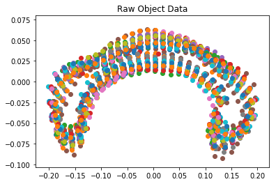

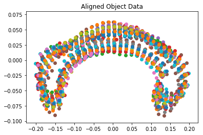

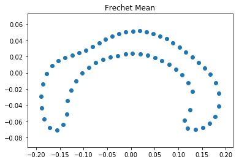

```python
# plot all objects
for shape in shapes:
    shape.plot()
axes = plt.gca()
# axes.set_xlim([-1,1])
# axes.set_ylim([-1,1])
plt.title('Raw Object Data')
plt.show()

mean = frechetMean(shapes, 10)

## plot aligned objects
alignedShapes = copy.deepcopy(shapes)
for shape in alignedShapes:
    shape.opa(mean)
    shape.plot()
axes = plt.gca()
# axes.set_xlim([-1,1])
# axes.set_ylim([-1,1])
plt.title('Aligned Object Data')
plt.show()

mean.plot()
axes = plt.gca()
# axes.set_xlim([-1,1])
# axes.set_ylim([-1,1])
plt.title('Frechet Mean')
plt.show()
```

The difference between before alignment and after alignment is noticable, but very subtle.

### Plot of Eigenvalues

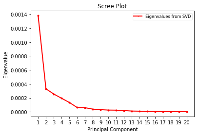

```python
# print(triangles[0].matrix)
# print(triangles[0].matrix.flatten())
flattenedShapes = []
for shape in shapes:
    flattenedShapes.append(shape.matrix.flatten())
flattenedShapes = np.array(flattenedShapes)
# print(flattenedTriangles.shape)
# print(flattenedTriangles)
eigenvalues, eigenvectors = pca(flattenedShapes)
sortedValueVectorPairs = sorted([(eigenvalues[i], eigenvectors[:, i]) for i in range(len(eigenvalues))], reverse=True)
sortedEigenvalues = [pair[0] for pair in sortedValueVectorPairs]
sortedEigenVectors = [pair[1] for pair in sortedValueVectorPairs]
# print(eigenvalues[:20])
# print(eigenvectors)
sing_vals = np.arange(eigenvalues.shape[0]) + 1
plt.plot(sing_vals[:20], sortedEigenvalues[:20], 'r.-', linewidth=2)
plt.xticks(sing_vals[:20])
plt.title('Scree Plot')
plt.xlabel('Principal Component')
plt.ylabel('Eigenvalue')
#I don't like the default legend so I typically make mine like below, e.g.
#with smaller fonts and a bit transparent so I do not cover up data, and make
#it moveable by the viewer in case upper-right is a bad place for it
leg = plt.legend(['Eigenvalues from SVD'], loc='best', borderpad=0.3,
                 shadow=False, prop=matplotlib.font_manager.FontProperties(size='small'),
                 markerscale=0.4)
leg.get_frame().set_alpha(0.4)
leg.draggable(state=True)
plt.show()
```

Above 6 modes, there isn't much variance to be gained from adding more modes, so I would use 6 modes to represent the data.

### Modes of Variation

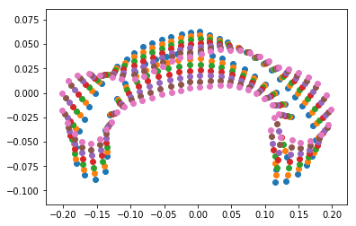

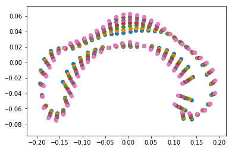

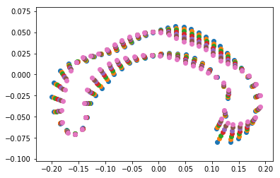

```python
for i in range(3):
    # largest eigen value
    lambda1 = sortedEigenvalues[i]
    v1 = sortedEigenVectors[i]
    # print(lambda1.real)
    # print(v1)
    v = np.real(v1.reshape(2, 64))
    # print(c)
    for t in range(-3, 4):
        mode = mean.expMap(t*lambda1.real**0.5*v)
    #     print(mode.matrix)
        mode.plot()
    #     plt.show()
    plt.show()
```

The first geodesic seems to capture curviture. Second one captures the size of the bump on top. The thrid one doesn't have an obvious characteristic. Looking at these figures, It makes sense that the first mode captures the most variance so the shapes in that figure also vary more than the second picture. The second plot also shows more variation than the thirdplot.

## Issues I Faced

- Used complex numbers first and then realized matrices are more convenient for multiplications and some other computation so I reimplemented
- Didn't know how to apply PUA to shapes until I learned in class that I could just convert the shapes to vectors